# RMarkdown Básico

Víctor Manuel Espinoza

15 de enero de 2021

**Ediciones**

El tamaño del texto de los encabezados y la importancia estará definido por el número de # que coloquemos antes del texto

# 1. # Tamaño grande

### 2. ### Tamaño mediano

##### 3. ##### Tamaño menor

También es posible agregar negritas y cursivas

Negrita: Escribir el texto como ** **Negrita** ** o __ **Negrita** __

Cursiva: Escribir el texto como * *Cursiva* * o _ *Cursiva* _

**Insertar imágenes**

[figure not shown]

**Ecuaciones**

#### Letras griegas y acentos matemáticos

Código: $\mu, \beta, \lambda, \sigma, \Sigma$

Código: $\tilde{S}, \overline{x}, \overline{X}, \hat{p}$

#### Subíndices, superíndices, comparaciones:

Código: $x_{i}$

Código: $x^{25}$

Código: $x_{i j}$

Código: $x^{2\cdot \alpha}, \tilde{S}^2,\sqrt{x}$

Código: $\mu=\mu_{0}$

Código: $3.141516\approx 3.14$

Código: $\mu\neq \mu_{0}$

Código: $\mu > \mu_{0}, \mu\geq \mu_{0}$

Código: $\mu < \mu_{0}, \mu\leq \mu_{0}$

#### Fracciones

Código: $\frac{\alpha}{2}$

Código: $z_{1-\frac{\alpha}{2}}, 8^{\frac{1}{3}}$

Código: $\frac{\tilde{S}}{\sqrt{n}}$

#### Paréntesis, corchetes y llaves:

Código: $(a,b); ]a,b[; \{a,b\}$

#### Ecuaciones complejas

Código: $f\left(k\right) = \binom{n}{k} p^k\left(1-p\right)^{n-k}$

**Listas**

#### Lista 1

- Elemento
- Elemento
  - Subelemento
    - Desagregación
- Elemento

#### Lista 2

1. Elemento
2. Elemento
3. Elemento

**Tablas**

Los primeros 15 renglones de nuestra base mtcars.

|  | mpg | cyl | disp | hp | drat | wt | qsec | vs |
| --- | --- | --- | --- | --- | --- | --- | --- | --- |
| Mazda RX4 | 21.0 | 6 | 160.0 | 110 | 3.90 | 2.620 | 16.46 | 0 |
| Mazda RX4 Wag | 21.0 | 6 | 160.0 | 110 | 3.90 | 2.875 | 17.02 | 0 |
| Datsun 710 | 22.8 | 4 | 108.0 | 93 | 3.85 | 2.320 | 18.61 | 1 |
| Hornet 4 Drive | 21.4 | 6 | 258.0 | 110 | 3.08 | 3.215 | 19.44 | 1 |
| Hornet Sportabout | 18.7 | 8 | 360.0 | 175 | 3.15 | 3.440 | 17.02 | 0 |
| Valiant | 18.1 | 6 | 225.0 | 105 | 2.76 | 3.460 | 20.22 | 1 |
| Duster 360 | 14.3 | 8 | 360.0 | 245 | 3.21 | 3.570 | 15.84 | 0 |
| Merc 240D | 24.4 | 4 | 146.7 | 62 | 3.69 | 3.190 | 20.00 | 1 |
| Merc 230 | 22.8 | 4 | 140.8 | 95 | 3.92 | 3.150 | 22.90 | 1 |
| Merc 280 | 19.2 | 6 | 167.6 | 123 | 3.92 | 3.440 | 18.30 | 1 |
| Merc 280C | 17.8 | 6 | 167.6 | 123 | 3.92 | 3.440 | 18.90 | 1 |
| Merc 450SE | 16.4 | 8 | 275.8 | 180 | 3.07 | 4.070 | 17.40 | 0 |
| Merc 450SL | 17.3 | 8 | 275.8 | 180 | 3.07 | 3.730 | 17.60 | 0 |
| Merc 450SLC | 15.2 | 8 | 275.8 | 180 | 3.07 | 3.780 | 18.00 | 0 |
| Cadillac Fleetwood | 10.4 | 8 | 472.0 | 205 | 2.93 | 5.250 | 17.98 | 0 |

**Aplicación**

La base de datos `CARS2004` del paquete `PASWR2` recoge el número de coches por 1000 habitantes (`cars`), el número total de accidentes con víctimas mortales (`deaths`) y la población/1000 (`population`) para los 25 miembros de la Unión Europea en el año 2004.

1. Proporciona con `R` resumen de los datos.
2. Utiliza la función `eda` del paquete `PASWR2` para realizar un análisis exploratorio de la variable `deaths`

#### Apartado 1

```r
library(PASWR2)
summary(CARS2004)
```

```
##            country        cars           deaths        population
##  Austria       : 1   Min.   :222.0   Min.   : 33.0   Min.   :  400
##  Belgium       : 1   1st Qu.:354.0   1st Qu.: 72.0   1st Qu.: 3446
##  Cyprus        : 1   Median :448.0   Median :112.0   Median : 8976
##  Czech Republic: 1   Mean   :432.1   Mean   :111.4   Mean   :18273
##  Denmark       : 1   3rd Qu.:491.0   3rd Qu.:135.0   3rd Qu.:16258
##  Estonia       : 1   Max.   :659.0   Max.   :222.0   Max.   :82532
##  (Other)       :19
```

Como puedes observar, al compilar tu documento aparecen las sentencias de `R` y el output que te da el programa.

#### Apartado 2

Ahora vamos a utilizar la función `eda` del paquete `PASWR2` para realizar un análisis exploratorio de la variable `deaths`

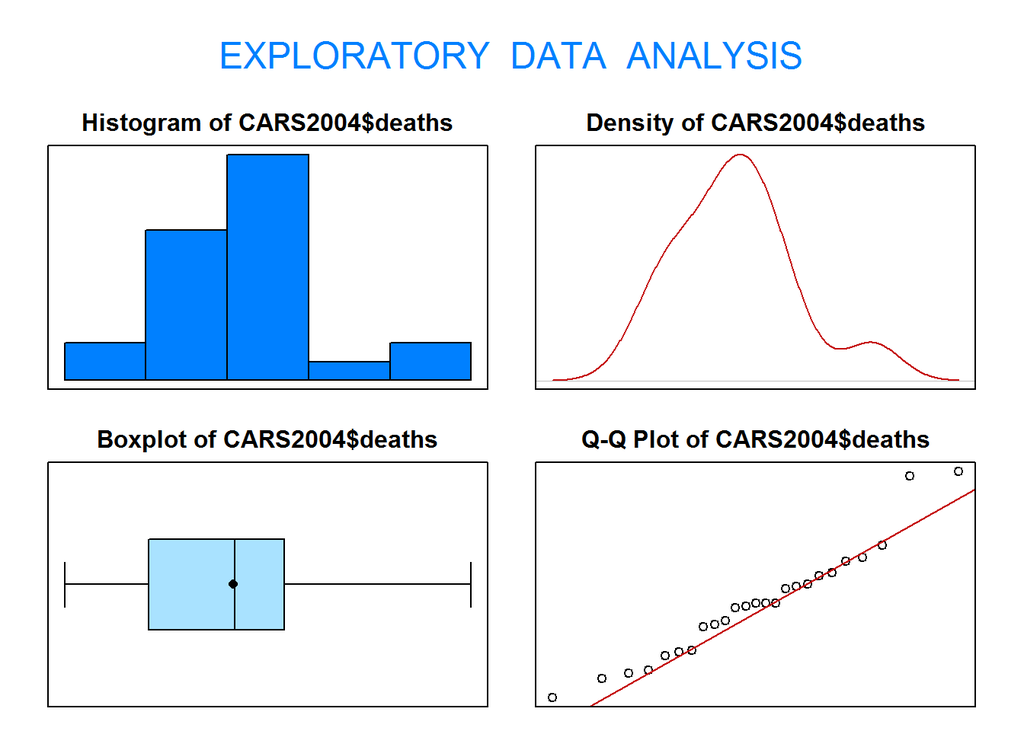

```
## Size (n)  Missing  Minimum   1st Qu     Mean   Median   TrMean   3rd Qu
##   25.000    0.000   33.000   72.000  111.400  112.000  110.000  135.000
##      Max    Stdev      Var  SE Mean   I.Q.R.    Range Kurtosis Skewness
##  222.000   47.023 2211.167    9.405   63.000  189.000    0.043    0.578
## SW p-val
##    0.243
```

```r
eda(CARS2004$deaths)
```

En este caso, en tu documento final te aparece el código de `R`, el output numérico de la función `eda` y el output gráfico de la función `eda`.